# Ch3: R-EDA: ggplot2

劉佳欣 Rafe C. H. Liu / Johnson Hsieh

Contact｜[Linkedin](http://tw.linkedin.com/in/rafechliu)

# 1. Data Visualization

- 清晰有效地傳達與溝通訊息
- 教學、研究、宣傳
- 美學、功能兼顧
- 統計圖形、訊息可視化
- [Chart suggestion](https://c4.staticflickr.com/4/3077/3196386402_01d8d12017_b.jpg)

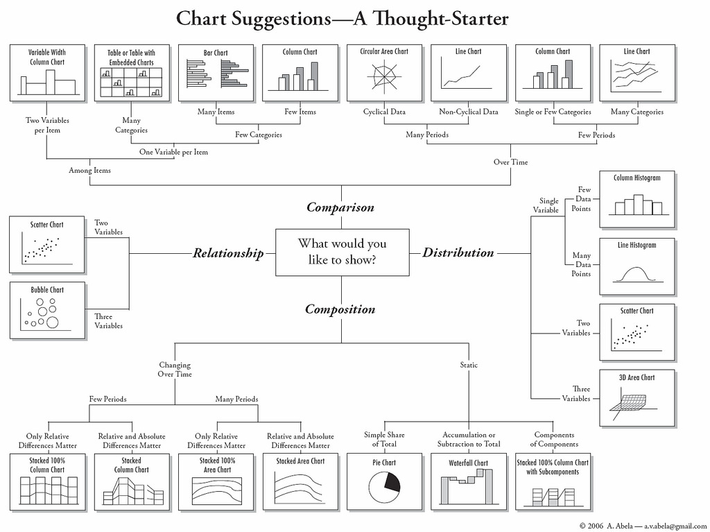

# 2. The grammar of graphics:

## 2.1. `library("ggplot2")`

- 當前最多人使用的視覺化R套件
- 取自 “The Grammar of Graphics” (Leland Wilkinson, 2005)
  - 由Hadley Wickham 於 2005 年發表 (Chief Scientist in RStudio)
- 設計理念
  - 採用圖層系統 (layer)
  - 用抽象的概念來控制圖形，避免細節繁瑣
  - 圖形美觀

## 2.2. 基礎語法

```r
library(ggplot2)
ggplot(data = df, aes(x = x, y = y)) +
   geom_point()
```

- ggplot() - for fine, granular control of everything
  - data layer:
    - data = data.frame
    - long-format (`library("reshape2"`)
    - aes(x = x, y = y)
  - geom layer: geom_xxx():
    - multi-layers: `+`
    - Geometric objects that define the basic “shape” of the elements on the plot
- 必備的參考資料
  - [ggplot2 cheatsheet](https://www.rstudio.com/wp-content/uploads/2015/03/ggplot2-cheatsheet.pdf)
  - [ggplot2 online help topics](http://docs.ggplot2.org/current/)
  - [Cookbook for R](http://www.cookbook-r.com/Graphs/)

```r
library(ggplot2)
# list all geom
ls(pattern = '^geom_', env = as.environment('package:ggplot2'))
```

```
 [1] "geom_abline"     "geom_area"       "geom_bar"        "geom_bin2d"      "geom_blank"
 [6] "geom_boxplot"    "geom_col"        "geom_contour"    "geom_count"      "geom_crossbar"
[11] "geom_curve"      "geom_density"    "geom_density_2d" "geom_density2d"  "geom_dotplot"
[16] "geom_errorbar"   "geom_errorbarh"  "geom_freqpoly"   "geom_hex"        "geom_histogram"
[21] "geom_hline"      "geom_jitter"     "geom_label"      "geom_line"       "geom_linerange"
[26] "geom_map"        "geom_path"       "geom_point"      "geom_pointrange" "geom_polygon"
[31] "geom_qq"         "geom_quantile"   "geom_raster"     "geom_rect"       "geom_ribbon"
[36] "geom_rug"        "geom_segment"    "geom_smooth"     "geom_spoke"      "geom_step"
[41] "geom_text"       "geom_tile"       "geom_violin"     "geom_vline"
```

# 3. 實例演練

## 3.1 Histogram

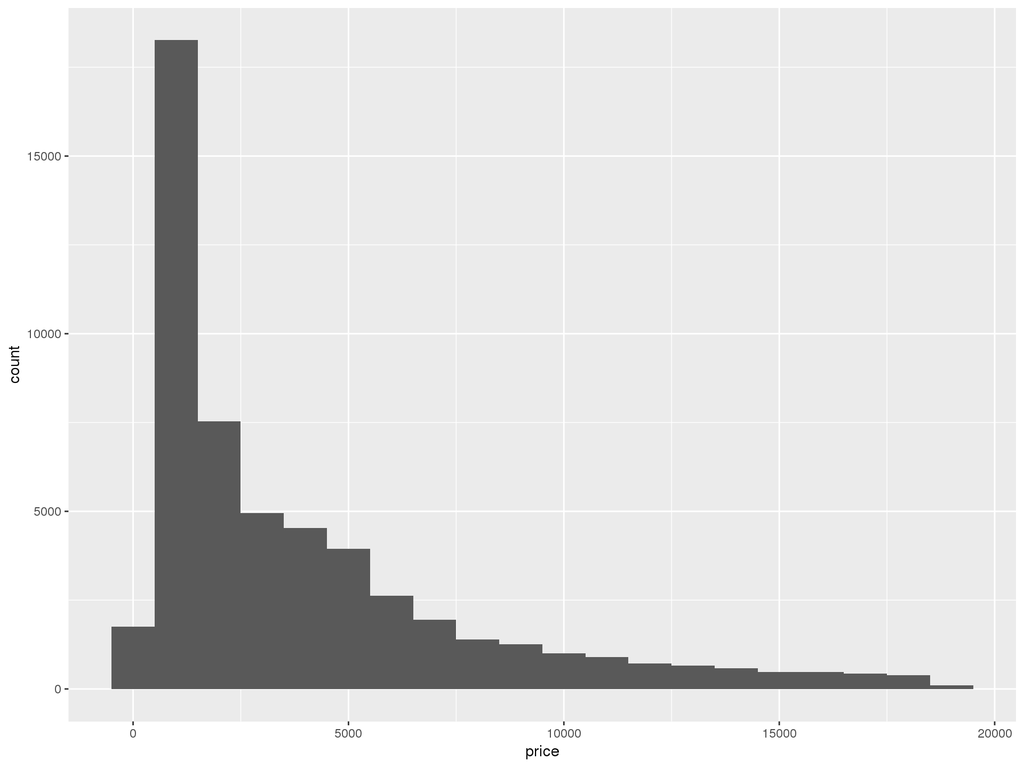

```r
# hist(diamonds$price)
ggplot(diamonds, aes(x=price)) +
  geom_histogram(binwidth=1000)
```

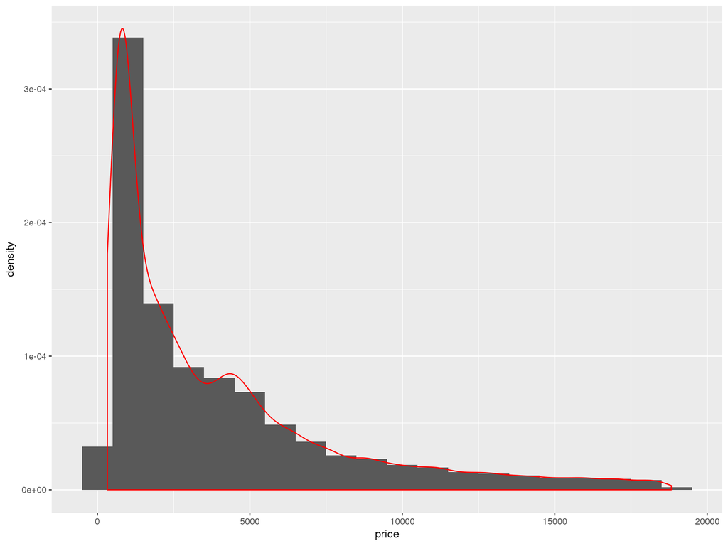

```r
# with density function
ggplot(diamonds, aes(x=price)) +
  geom_histogram(aes(y=..density..), binwidth=1000) +
  geom_density(color="red")
```

## 3.2 Barchart

- Plot by counting (default)

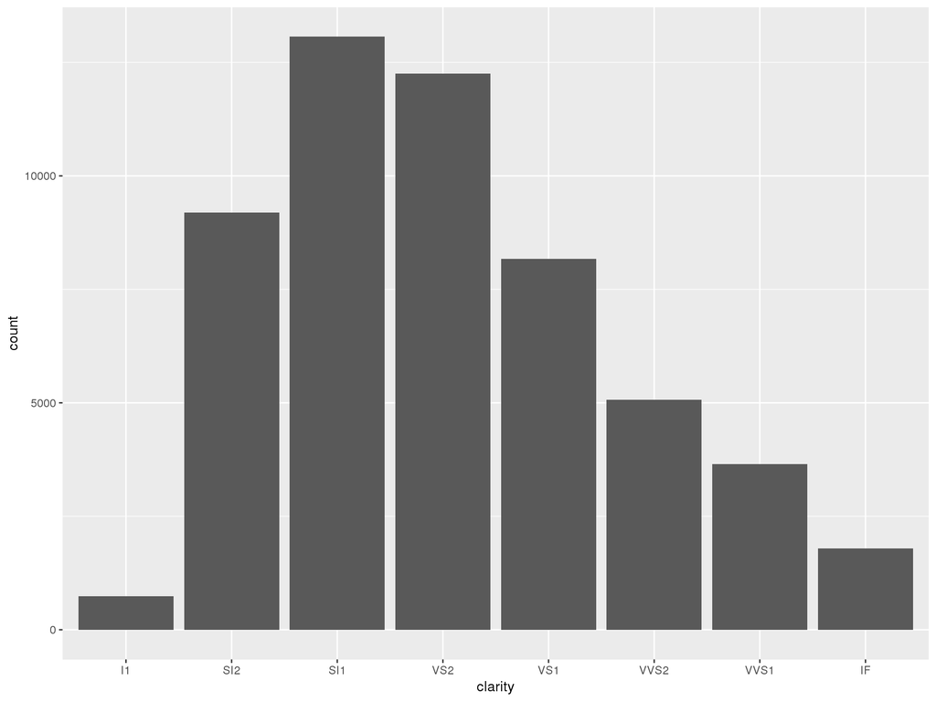

```r
# counts <- table(diamonds$clarity)
# barplot(counts, main="Car Distribution",
#       xlab="Number of Gears")

# by default, stat = "bin"
ggplot(diamonds, aes(x=clarity)) +
  geom_bar()
```

- Use stat = “identity” argument

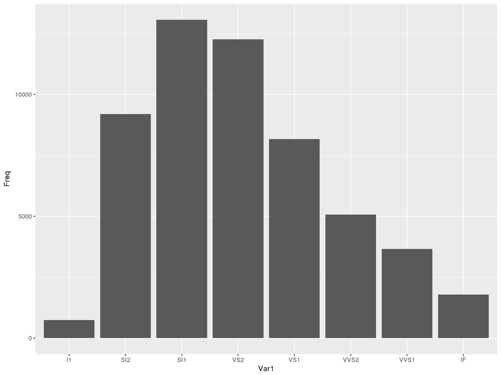

```r
tab <- data.frame(table(diamonds$clarity))
ggplot(tab, aes(x=Var1, y=Freq)) +
  geom_bar(stat="identity")
```

- Add fill layer

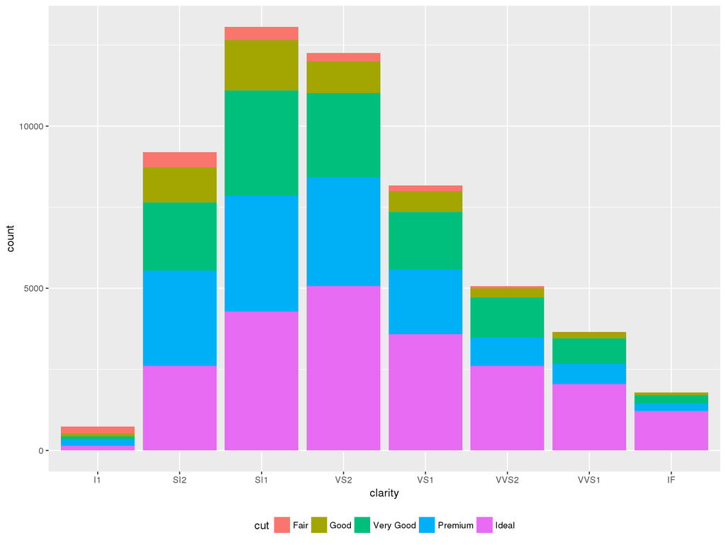

```r
# change legend position
ggplot(diamonds, aes(x=clarity, fill=cut)) +
  geom_bar(position="stack") +
  theme(legend.position="bottom")
```

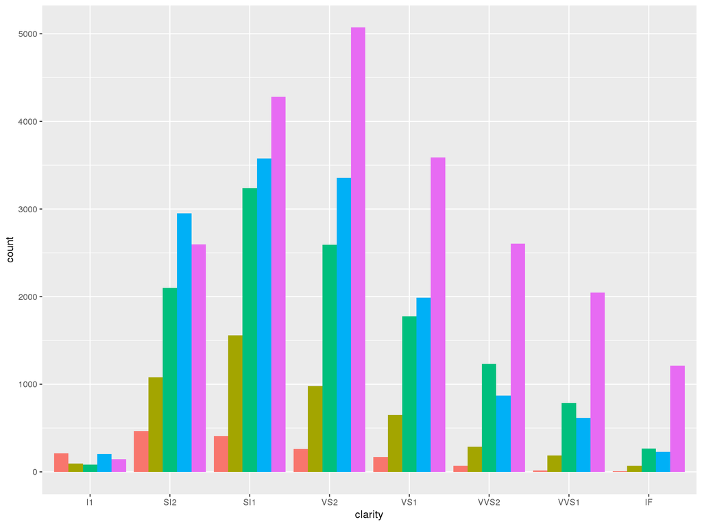

```r
ggplot(diamonds, aes(x=clarity, fill=cut)) +
  geom_bar(position="dodge") +
  theme(legend.position="NULL")
```

- Change coord layer

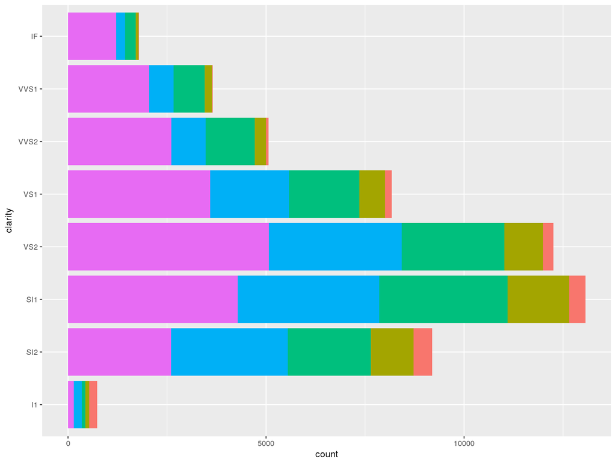

```r
ggplot(diamonds, aes(x=clarity, fill=cut)) +
  geom_bar() + coord_flip() +
  theme(legend.position="NULL")
```

- Set theme layer

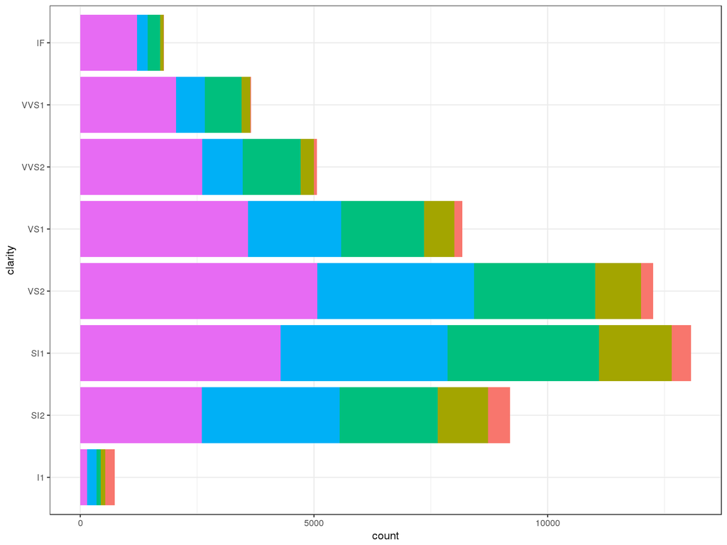

```r
g <- ggplot(diamonds, aes(x=clarity, fill=cut))
g + geom_bar() + coord_flip() + theme_bw() +
  theme(legend.position="NULL")
```

## 3.3 pie chart

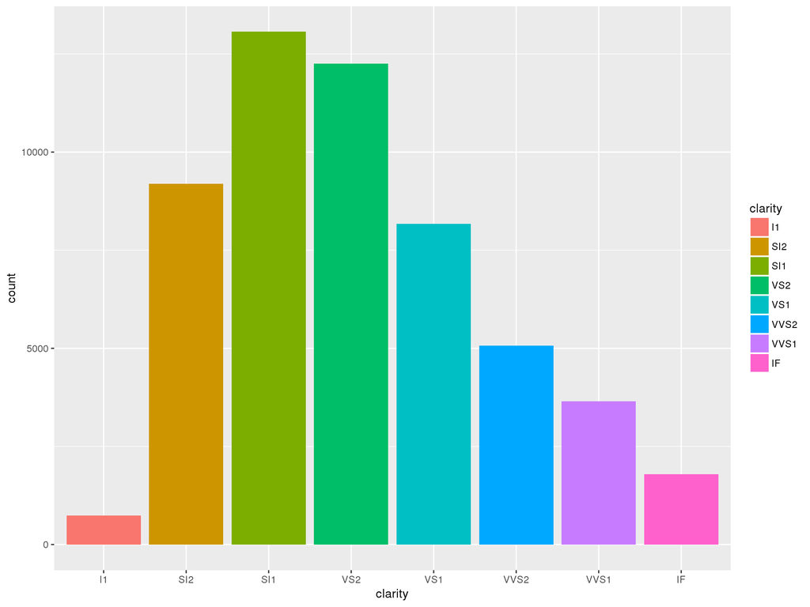

```r
ggplot(diamonds, aes(x=clarity, fill=clarity)) +
  geom_bar()
```

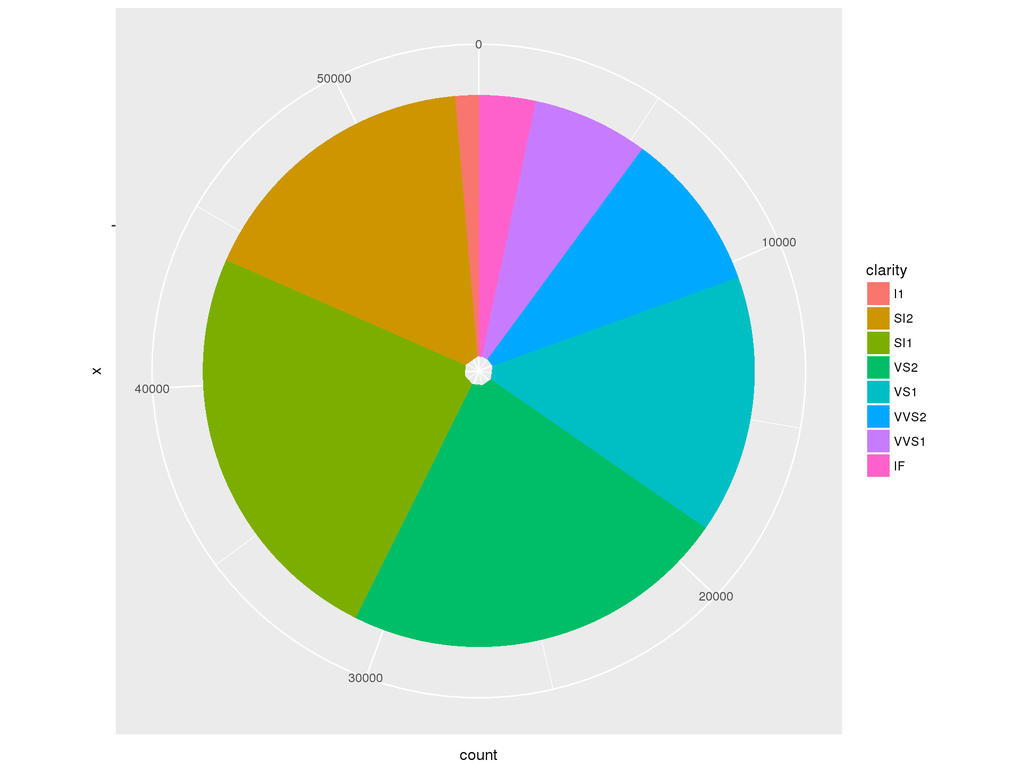

```r
ggplot(diamonds, aes(x="", fill=clarity)) +
  geom_bar() +
  coord_polar(theta = "y")
```

## 3.4 Line chart

```r
library(dplyr)
head(economics)
```

```
# A tibble: 6 x 6
        date   pce    pop psavert uempmed unemploy
      <date> <dbl>  <int>   <dbl>   <dbl>    <int>
1 1967-07-01 507.4 198712    12.5     4.5     2944
2 1967-08-01 510.5 198911    12.5     4.7     2945
3 1967-09-01 516.3 199113    11.7     4.6     2958
4 1967-10-01 512.9 199311    12.5     4.9     3143
5 1967-11-01 518.1 199498    12.5     4.7     3066
6 1967-12-01 525.8 199657    12.1     4.8     3018
```

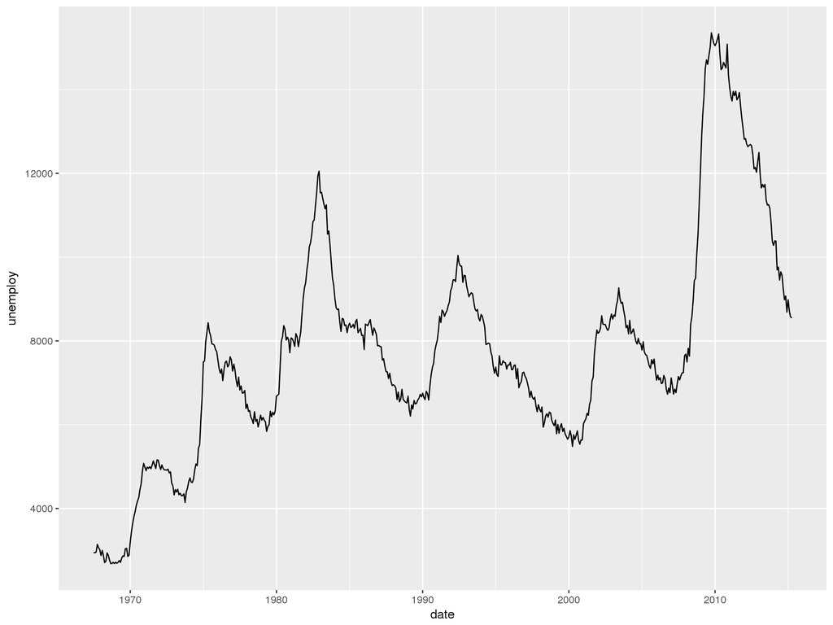

```r
econ <- economics %>%
          mutate(year = strftime(date, format = "%Y"),
                 month = strftime(date, format = "%m"))

ggplot(econ, aes(x = date, y = unemploy)) +
  geom_line()
```

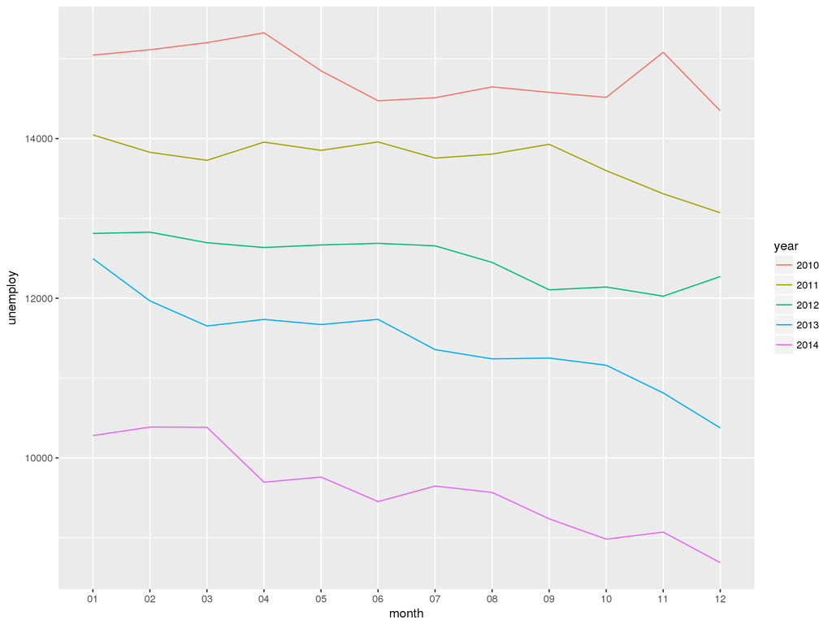

```r
econ %>% filter(year %in% c("2010", "2011","2012", "2013", "2014")) %>%
  group_by(year) %>%
  ggplot(aes(x = month, y = unemploy, group = year, colour = year)) +
  geom_line()
```

## 3.5 Scatterplot

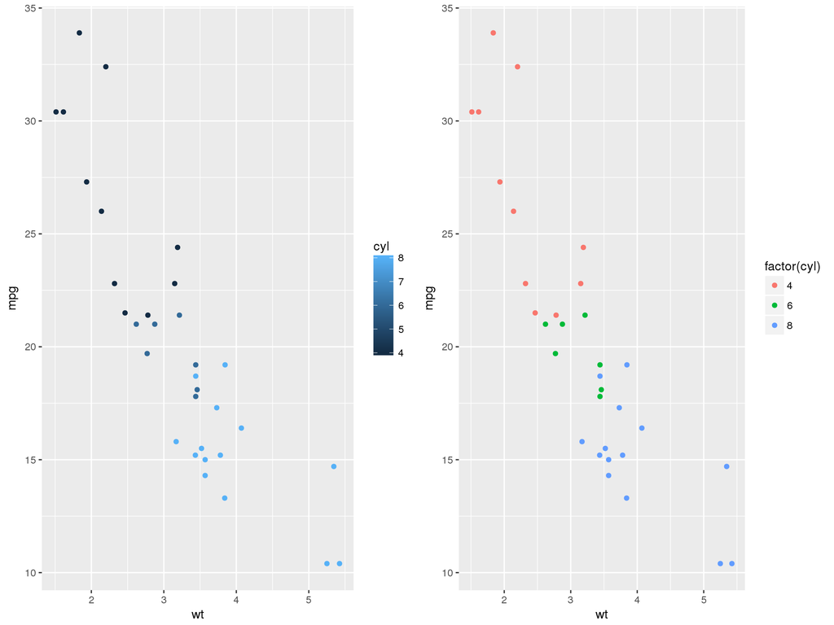

```r
g1 <- ggplot(mtcars, aes(x=wt, y=mpg, colour=cyl)) + geom_point()
g2 <- ggplot(mtcars, aes(x=wt, y=mpg, colour=factor(cyl))) + geom_point()
library(gridExtra)
grid.arrange(g1, g2, ncol=2)
```

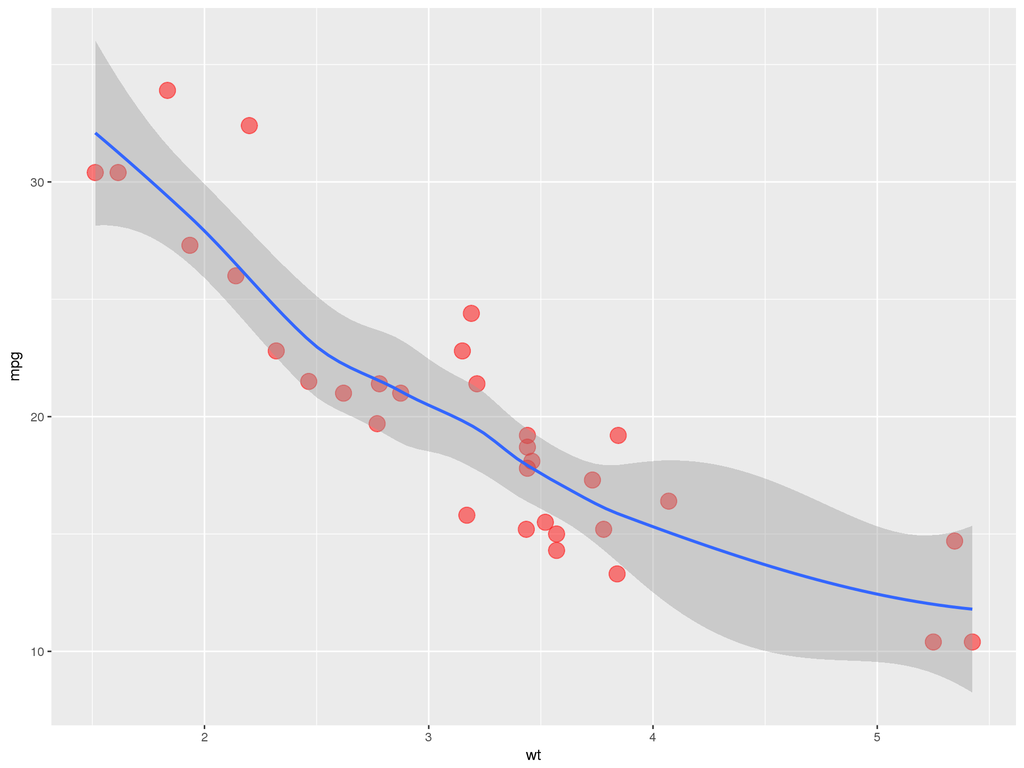

```r
# Add stat_xxx layer
ggplot(mtcars, aes(x=wt, y=mpg)) +
  geom_point(color="red", size=5, alpha=0.5) +
  stat_smooth()
```

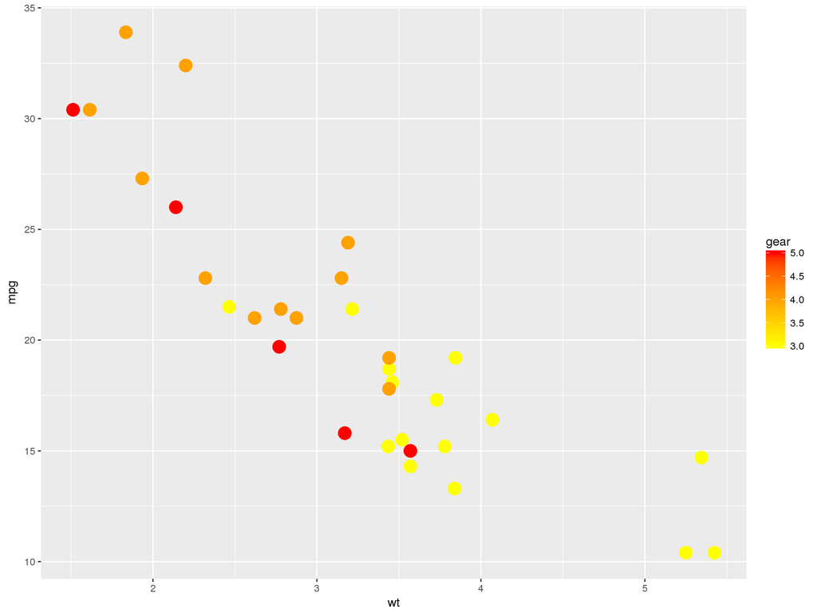

```r
# Add scale_xxx layer
ggplot(mtcars, aes(x=wt, y=mpg, colour=gear)) +
  geom_point(size=5) +
  scale_color_continuous(low="yellow", high="red")
```

## 3.6 facet_

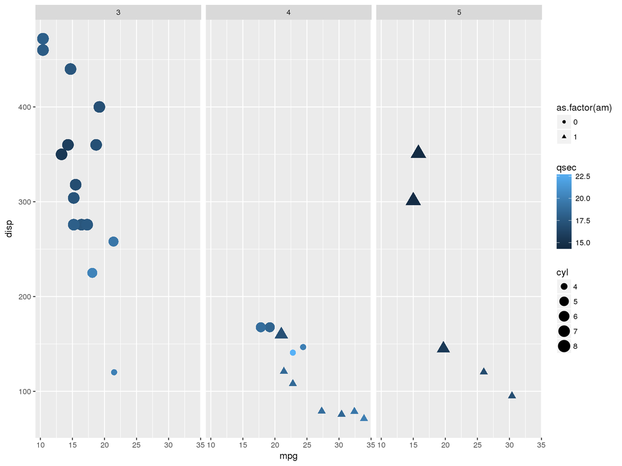

```r
ggplot(mtcars, aes(x=mpg, y=disp)) +
  geom_point(aes(colour=qsec, size=cyl, shape=as.factor(am))) +
  facet_wrap(~gear) +
  scale_size(range=c(3,6))
```

# What’s the next

- ETL => EDA => MODEL => `THESIS`
- Keep playing with R
  - ETL: dplyr, data.table, sparkR, …
  - Interactive web applications: rmarkdown, plotly, highchart, shiny
  - Distributed computing: Rmpi, …
  - Spatial Visualization: ggmap, …
  - Web scraping: xml2, rvest…

Thanks!  
Rafe C.H. Liu｜Contact｜[Linkedin](http://tw.linkedin.com/in/rafechliu)

UPDATE: 2017-12-01